**Optiver 9: Predicting Volatility with Model Comparisons Across Stocks with Differing Characteristics**

# Executive Summary:

## Research Question:

**“How do traditional (AREWMA, EGARCH), hybrid (GARCH + LSTM), and machine-learning (LSTM, XGBoost) approaches compare in forecasting Friday’s intraday volatility from Monday–Thursday order-book features, and does clustering by microstructure characteristics influence their predictive accuracy?”**

## Motivation and Problem Formulation:

Accurately forecasting long-term volatility is crucial for trading, market making, and risk management, as traders employ various quantitative models to inform their decisions. A model for forecasting Friday volatility based on Monday to Thursday-data could offer insights for building risk-aware and actionable trading strategies.

Traditional models are valued for interpretability and work well on linear patterns (Eliasson, 2023). However, they struggle with the nonlinear dynamics common in high-frequency financial data. Machine learning models like Long Short-Term Memory (LSTM, hereafter) and Extreme Gradient Boost (XGBoost, hereafter) excel in such settings but are less interpretable and more data-hungry (Hochreiter & Schmidhuber, 1997). A hybrid model of Generalized Autoregressive Conditional Heteroskedasticity (GARCH, hereafter) combined with LSTM may offer a balanced approach, combining statistical structure with data-driven flexibility.

## Key Findings and Recommendations:

Recommendations for the following model use cases:  
XGBoost for stocks with non-linear, noisy or highly volatile behaviour.  
LSTM for more moderate, but still highly accurate predictions.  
Traditional models for smoother, more interpretable forecasts.  
Hybrid models to capture complexities but with caution with scaling of forecasts.

# Background

Volatility forecasting plays a vital role in modern financial markets, where short-term price uncertainty directly informs trading strategies, market making, and portfolio risk management (Eliasson, 2023; Teller & Pigorsch, 2022).

Traditional statistical models such as GARCH estimate volatility by assuming that conditional variance evolves from past squared returns and prior variance (Bollerslev, 1986). While GARCH-based methods offer strong interpretability and have been widely used in finance, they often fail to capture the nonlinear and non-stationary nature of high-frequency financial data (Andersen, Bollerslev, & Lange, 1999).

This project investigates whether combining GARCH with deep learning methods, such as LSTM networks, can produce more accurate and robust forecasts. Unlike classical models, LSTMs are capable of learning complex temporal patterns from sequential data but typically require large, clean datasets and careful tuning to avoid overfitting.

## Data Source and Descriptions

The dataset used in this study originates from Optiver and comprises high-frequency order book data sampled every 60 seconds. Each row captures a snapshot of the top levels of the order book during trading hours, recorded across 99 consecutive weeks. Raw features in the dataset include:

stock_id, time_id, seconds_in_bucket  
Bid and ask prices and volumes at multiple levels  
From these base features, we engineered several additional variables essential for volatility prediction:  
**Mid-price** and **log returns**  
**Weighted Average Price (WAP)**  
**Bid-ask spread** and **spread asymmetry**  
**Order imbalance** (difference between bid and ask volumes)  
**Realised volatility** (target variable, computed hourly from log returns)  
**Time bucket ID** (for aggregating sequential windows)  
These engineered features capture both price dynamics and microstructure characteristics, offering a rich input set for model training.

## Exploratory Data Analysis (EDA)

We selected the additional Optiver dataset of 10 stocks with longer sequential time frames to fit our motivation of developing a forecasting product that traders can adapt and interpret. Hence, using this data we explored the volatility over a 99-trading week subset. This ensured that all models, particularly those sensitive to sequence integrity, could be trained and evaluated on consistent input data without requiring imputation or padding.

From the raw order book data, we engineered several key microstructure features: Weighted Average Price (WAP), bid-ask spread, order imbalance, spread asymmetry, and log returns. The target variable, realised volatility, was calculated as the square root of the sum of squared log returns within each time window.

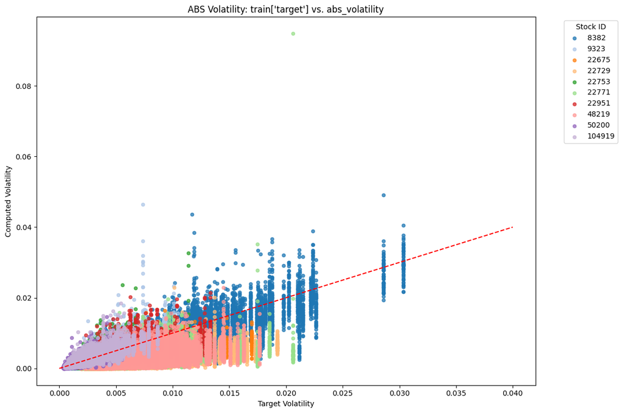

```
Mean Error: -0.0018588941165900309
Mean Absolute Error: 0.002048379707920408
```

```python
import pandas as pd
import matplotlib.pyplot as plt

df_combined = pd.read_parquet(
    "/Users/shiyuchen/Downloads/DATA3888_Optiver_9_GroupCode/AREWMA_Model/merged_order_book_combined.parquet"
)
train = pd.read_csv(
    "/Users/shiyuchen/Downloads/DATA3888_Optiver_9_GroupCode/AREWMA_Model/train.csv"
)

myRV = df_combined[['stock_id', 'time_id', 'abs_volatility']].drop_duplicates()
compare = myRV.merge(train, on=['stock_id', 'time_id'], how='inner')

unique_stocks = sorted(compare['stock_id'].unique())
cmap = plt.get_cmap('tab20')
colors = {sid: cmap(i % cmap.N) for i, sid in enumerate(unique_stocks)}

plt.figure(figsize=(12, 8))
for sid in unique_stocks:
    data = compare[compare['stock_id'] == sid]
    plt.scatter(
        data['target'],
        data['abs_volatility'],
        label=str(int(sid)),
        color=colors[sid],
        s=20,
        alpha=0.75
    )

plt.plot([0, 0.04], [0, 0.04], linestyle='--', color='red')
plt.xlabel("Target Volatility")
plt.ylabel("Computed Volatility")
plt.title("ABS Volatility: train['target'] vs. abs_volatility")
plt.legend(title="Stock ID", bbox_to_anchor=(1.05, 1), loc="upper left")
plt.tight_layout()
plt.show()

compare['error'] = compare['abs_volatility'] - compare['target']
print("Mean Error:", compare['error'].mean())
print("Mean Absolute Error:", compare['error'].abs().mean())
```

Figure 1

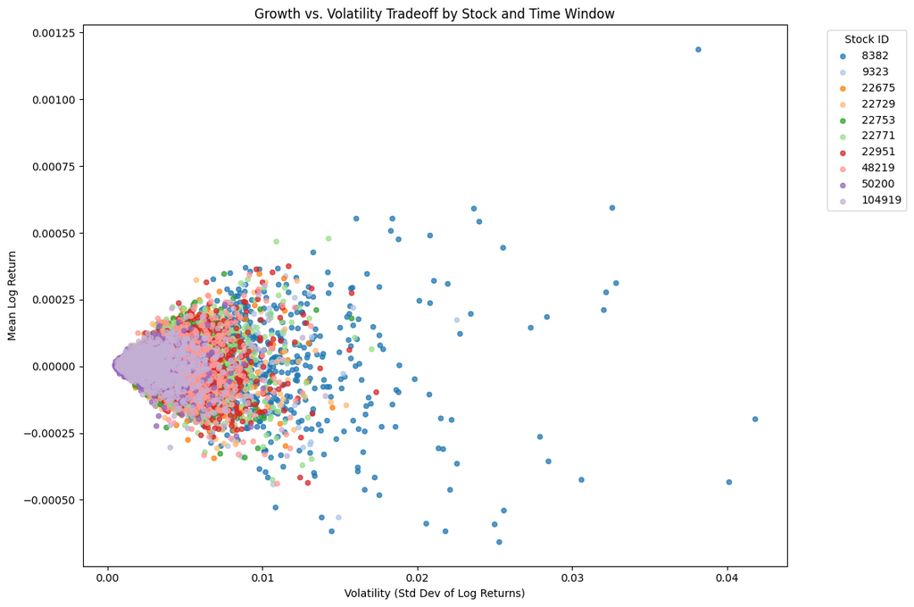

```python
import numpy as np
import pandas as pd
import matplotlib.pyplot as plt

# 计算 log_return_set
df_combined['log_return_set'] = df_combined['log_ret_sum']

def growth_vs_volatility_matplotlib(df):
    if 'log_return_set' not in df.columns:
        raise ValueError("compute 'log_return_set' first")

    mean_return = (
        df.groupby(['stock_id', 'time_id'])['log_return_set']
          .mean()
          .reset_index()
          .rename(columns={'log_return_set': 'mean_log_return'})
    )

    realized_vol = (
        df.groupby(['stock_id', 'time_id'])['log_return_set']
          .agg(lambda x: np.sqrt((x**2).sum()))
          .reset_index()
          .rename(columns={'log_return_set': 'abs_volatility'})
    )

    tradeoff_df = pd.merge(
        mean_return,
        realized_vol,
        on=['stock_id', 'time_id'],
        how='inner'
    )


    unique_stocks = sorted(tradeoff_df['stock_id'].unique())
    cmap = plt.get_cmap('tab20')
    colors = {sid: cmap(i % cmap.N) for i, sid in enumerate(unique_stocks)}

    plt.figure(figsize=(12, 8))
    for sid in unique_stocks:
        data = tradeoff_df[tradeoff_df['stock_id'] == sid]
        plt.scatter(
            data['abs_volatility'],
            data['mean_log_return'],
            label=str(int(sid)),
            color=colors[sid],
            s=20,
            alpha=0.75
        )

    plt.xlabel("Volatility (Std Dev of Log Returns)")
    plt.ylabel("Mean Log Return")
    plt.title("Growth vs. Volatility Tradeoff by Stock and Time Window")
    plt.legend(title="Stock ID", bbox_to_anchor=(1.05, 1), loc="upper left")
    plt.tight_layout()
    plt.show()

    return tradeoff_df

log_return_stats = growth_vs_volatility_matplotlib(df_combined)
```

Figure 2

# Methods

## Data Collection

Additionally, we took a random subset of 99 weeks, 33 weeks for each cluster, due to model runtimes and trained models on the first 4 days before predictions on Friday. Further, to simulate live market conditions for prediction use a 30-minute rolling window, with the model incrementally retrained every half-hour.

## Model Development

### Traditional Models

**AREWMA**

A traditional statistics model where more recent measurements are given greater weight than past. Has a parameter, the decay factor $\lambda$, which determines the weight given to the previous day's estimate.

$$\sigma^{2}_{t+1} = \lambda \sigma^{2}_{t} + (1 - \lambda )u^{2}_{t}$$

**With:**

- $\sigma^{2}_{t}$: estimated variance, day t
- $\lambda$: decay factor, between 0 and 1
- $u^{2}_{t}$: squared return, day t

**EGARCH**

Similar to other GARCH models, EGARCH assigns greater weight to more recent observations. However, it differs by accommodating parameter asymmetry, allowing it to capture the leverage effect. These effects assume that negative shocks have a different impact on volatility than positive shocks. For our implementation, we selected a simple (1, 1, 1) specification for the hyperparameters (p, q, r), as the primary lag structures were adequately captured with first-order terms.

**Parameters/Variables:**

- $\omega$: Constant
- $\beta_i$: Coefficients for lagged log variances
- $\alpha_j$: Coefficients for lagged absolute standardized residuals
- $\gamma_k$: Coefficients for asymmetry
- $\epsilon_t$: Residual at t

### Machine Learning Models

**LSTM**

A type of recurrent neural network (RNN) that captures long-term dependencies in sequential data (Hochreiter & Schmidhuber, 1997). Whereby, there are various hyper parameters to tune and are quite complex to interpret.

**Forget Gate:** $$f_t = \sigma(W_f \cdot x_t + U_f \cdot h_{t-1} + b_f)$$

**Input Gate:** $$i_t = \sigma(W_i \cdot x_t + U_i \cdot h_{t-1} + b_i)$$

**Candidate Cell State:** $$\tilde{c}_t = \tanh(W_c \cdot x_t + U_c \cdot h_{t-1} + b_c)$$

**Cell State Update:** $$c_t = f_t \odot c_{t-1} + i_t \odot \tilde{c}_t$$

**Output Gate:** $$o_t = \sigma(W_o \cdot x_t + U_o \cdot h_{t-1} + b_o)$$

**Hidden State Update:** $$h_t = o_t \odot \tanh(c_t)$$

**Parameters/Variables:**

- $x_t$: Input at time t
- $W_f, W_i, W_c, W_o$: Weight matrices at different gates
- $U_f, U_i, U_c, U_o$: Recurrent weight matrices
- $b_f, b_i, b_c, b_o$: Bias terms
- $\sigma$: Sigmoid function
- $\odot$: Element-wise multiplication (Hadamard product)

**XGBoost**

This model boosts decision trees by sequentially fitting residuals to improve predictions known for its high predictive accuracy and efficient training, it handles nonlinear patterns and interactions well.

**XGBoost aims to minimize:** $$L(\theta) = \sum_{i=1}^{n} l(y_i, \hat{y}_i) + \sum_{k=1}^{K} \Omega(f_k)$$

Where:

- $l(y_i, \hat{y}_i)$: the loss function
- $\Omega(f_k)$: regularization term for model complexity

**Using an additive approach:** $$\hat{y}_i = \sum_{k=1}^{K} f_k(x_i)$$

where $f_k(x_i)$ is the prediction for k-th weak learner.

**Parameters/Variables:**

- $y_i$: True value of target
- $\hat{y}_i$: Predicted value
- $x_i$: Input feature vector for sample i
- $\theta$: Parameters
- $K$: Number of trees
- $\Omega(f_k)$: Regularization term for preventing overfitting
- $l(y_i, \hat{y}_i)$: Loss function
- $\sum$: Summation symbol

### Hybrid Model

**GARCH-LSTM**

The Hybrid model combines the strengths of LSTM (for capturing nonlinear and long-term dependencies) and GARCH (for modelling volatility clustering and mean reversion). With the GARCH component estimating the conditional variance of a financial time series the GARCH-generated residuals are inputted to an LSTM network. Consequently, the strengths of both models together translate to combined limitations in terms of complexity and interpretability.

## Evaluation Motivations

Qualitative evaluations include computational complexity and interpretation, whereby machine learning models and more so the hybrid model, are harder to interpret and will be weighed against other evaluations. With consideration of traders, simpler interpretations would allow the audience to adapt our end product to various situations with ease.

Further, graphical evaluations allow us to make sense of model complexity and perhaps reasons for quantitative results. This type of evaluation is perhaps most important for our audience to use our product to make actionable decisions for trading, with a combination of our models capturing both the right scale and complex patterns of the forecast output.

# Results

## Evaluation

### Quantitative

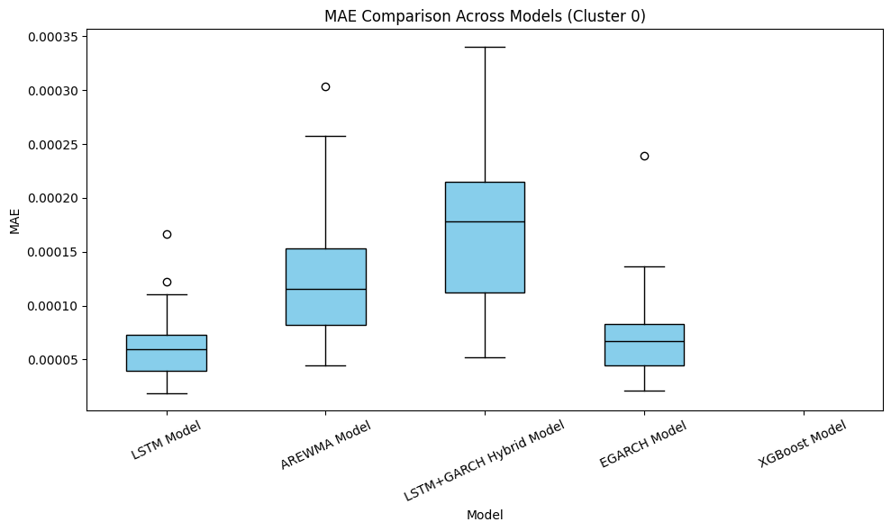

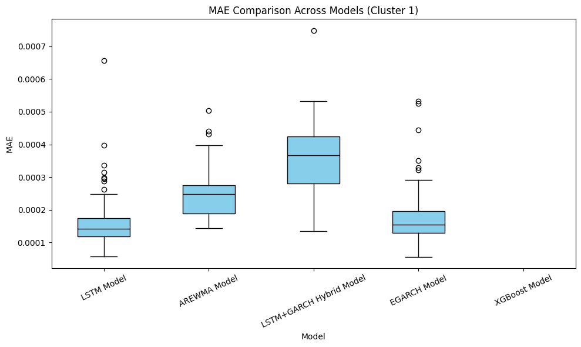

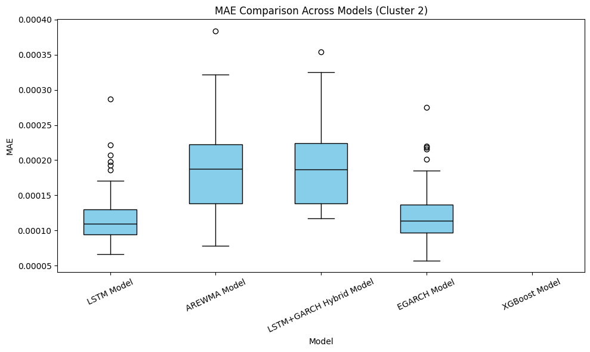

```python
import pandas as pd
import matplotlib.pyplot as plt

cluster_df = pd.read_csv('cluster_df.csv')
metrics = pd.read_csv('metrics.csv')
lstm = pd.read_csv('LSTM_new_weekly_metrics.csv')
xgb = pd.read_csv('XGB_weekly_metrics.csv')
egarch = pd.read_csv('EGARCH_new_weekly_metrics.csv')
hybrid = pd.read_csv('hybrid_metrics.csv')

arewma_df = metrics[metrics["model"] == "AR-EWMA"][["stock", "week", "MAE"]].copy()
arewma_df["model"] = "AREWMA Model"

lstm_df = lstm[["stock", "week", "MAE"]].copy()
lstm_df["model"] = "LSTM Model"

xgb_df = xgb[xgb["model"] == "XGBoost"][["stock", "week", "MAE"]].copy()
xgb_df["model"] = "XGBoost Model"

egarch_df = egarch[["stock", "week", "MAE"]].copy()
egarch_df["model"] = "EGARCH Model"

hybrid_df = hybrid[["stock", "week", "MAE"]].copy()
hybrid_df["model"] = "LSTM+GARCH Hybrid Model"

metrics_all = pd.concat(
    [arewma_df, lstm_df, xgb_df, egarch_df, hybrid_df],
    ignore_index=True
)

metrics_all["stock"] = metrics_all["stock"].astype(int)
cluster_df["stock_id"] = cluster_df["stock_id"].astype(int)

merged = metrics_all.merge(
    cluster_df,
    left_on=["stock", "week"],
    right_on=["stock_id", "week"],
    how="left"
).dropna(subset=["cluster"])

for c in sorted(merged["cluster"].unique()):
    cluster_data = merged[merged["cluster"] == c]

    order = ["LSTM Model", "AREWMA Model", "LSTM+GARCH Hybrid Model", "EGARCH Model", "XGBoost Model"]
    data_to_plot = [cluster_data[cluster_data["model"] == m]["MAE"].values for m in order]

    plt.figure(figsize=(10, 6))

    box_plot = plt.boxplot(data_to_plot, labels=order, notch=False, patch_artist=True)

    for patch in box_plot['boxes']:
        patch.set_facecolor('#87CEEB')
        patch.set_edgecolor('black')
        patch.set_linewidth(1)

    for median in box_plot['medians']:
        median.set_color('black')
        median.set_linewidth(1)

    for whisker in box_plot['whiskers']:
        whisker.set_color('black')
        whisker.set_linewidth(1)

    for cap in box_plot['caps']:
        cap.set_color('black')
        cap.set_linewidth(1)

    plt.title(f"MAE Comparison Across Models (Cluster {int(c)})")
    plt.ylabel("MAE")
    plt.xlabel("Model")
    plt.xticks(rotation=25)
    plt.tight_layout()
    plt.show()
```

Figure 3

### Qualitative

Computationally, the traditional models were the quickest to train, followed by machine learning and then the hybrid. As we are doing long-term predictions, longer computational time could be excused for the trade offs with other metrics. Therefore, as the longest time with the hybrid model took on average just over a minute to train and perform updates, with a combination of the other metrics, the longer computational time of the machine learning models is still adequate.

Further, the complex hyperparameter tuning of the machine learning and hybrid models can cause interpretation problems. Given LSTM as an example, the deep learning of neural networks require various hyperparameters. We chose the hyperparameters based on runtime constraints with training and with additional training in the hybrid model made interpretation more complex. Therefore, if the traders were to adapt our more complex models, would be inefficient.

## Deployment

The volatility dashboard was deployed on Railway, a cloud platform enabling seamless web app hosting directly from the public GitHub repository. The product is an interactive Panel-based web app with three tabs: predictive visualization for selected stocks and models, performance evaluation across clusters using statistical metrics, and comparative analysis of model effectiveness.

This tool provides a user-friendly way for, people without any data science knowledge to pick and choose the model they think works best for their volatility predictions, giving the user five models to choose from, namely: LSTM, E-GARCH, AR-EWMA, LSTM+GARCH (Hybrid model), and XG-Boost.

It was developed and deployed with financial traders in mind for convenient and fast volatility predictions. Concepts from statistics (e.g., IQR-based outlier removal, prediction error metrics), machine learning, and data engineering (time format standardization, column harmonization) are integrated.

# Discussion

## Limitations

The primary issue with our analysis is that the Long Horizon Forecasting and Rolling Window approach may inherently favour machine learning models, as they are capable of capturing complex, non-linear, and temporal dependencies in the data over time, leading to better performance and predictions. As opposed to traditional models that assume linearity in the data.

Another limitation was the surface-level nature of our hyperparameter tuning. Due to computational and time constraints, we restricted our exploration of the parameter space to a small set of chosen values. This limited search, coupled with the absence of robust cross-validation, may have led to suboptimal model configurations.

Furthermore, runtime considerations forced trade-offs that prioritized efficiency over model performance, reducing the likelihood of finding globally optimal hyperparameter settings. We also failed to show uncertainty (e.g., confidence bands) around predictions of our models.

## Future Steps

We could do the following in the future to further refine our analysis:  
Expand hyperparameter tuning through a more comprehensive search space and implement cross-validation techniques to improve model robustness.  
Incorporate uncertainty quantification methods, such as prediction intervals or confidence bands, to better evaluate forecast reliability.  
Allocate additional computational resources to enable deeper model optimization and reduce the need for performance-efficiency trade-offs.

# Conclusion

In conclusion, this framework offers a scalable, adaptive methodology for high-frequency volatility forecasting. It equips analysts and risk managers with actionable insights for model selection, portfolio-specific calibration, and strategic deployment in dynamic market environments.

# Student Contributions

**Yuchen Shi (530230016) (Chris)**  
Chris developed the LSTM model and took charge of most of the interactive dashboard. He successfully deployed it to the cloud, reworked the underperforming EGARCH model, and debugged both the XGBoost model and EDA. He also designed the final HTML template, and made HTML in final report.

**Priyongkar Kundu (520518054)**  
Performed data processing including the cleaning of data, calculation of additional variables and performed clustering. Responsible for investigating and producing XGBoost model code and collaborated with dashboard deployment. Created final markdown report, pulling together code outputs with report writing.

**Emilija Vidakovic (530490182)**  
Investigated secondary sources for the GARCH-LSTM model and built the code for this model. Organised the design of the boxplot metrics for each cluster and result observations. Was also responsible for the model development and results sections of the report and the content layout of the presentation.

**Ryan Lam (520268067)**  
Led initial data exploration and created visualisations to support cluster analysis. Contributed to the development and analysis of GARCH model variations. Assisted in writing refining, and editing the final report, and collaborated on presentation content.

**Nicole Paikkatt (520617829)**  
Responsible for developing the AR-EWMA volatility forecasting model and contributing significantly to the report writing and presentation design. As well as managing team meetings to ensure smooth collaboration and effective task execution.

# References

Andersen, T. G., Bollerslev, T., & Lange, S. (1999). Forecasting financial market volatility: Sample frequency vis-à-vis forecast horizon. Journal of Empirical Finance, 6(4), 457–477.

Bollerslev, T. (1986). Generalized autoregressive conditional heteroskedasticity. Journal of Econometrics, 31(3), 307–327. https://doi.org/10.1016/0304-4076(86)90063-1

Chen, T., & Guestrin, C. (2016). XGBoost: A scalable tree boosting system. In Proceedings of the 22nd ACM SIGKDD International Conference on Knowledge Discovery and Data Mining (pp. 785–794). https://doi.org/10.1145/2939672.2939785

Eliasson, E. (2023). Long horizon volatility forecasting using GARCH-LSTM hybrid models: A comparison between volatility forecasting methods on the Swedish stock market. KTH Royal Institute of Technology.

Hochreiter, S., & Schmidhuber, J. (1997). Long short-term memory. Neural Computation, 9(8), 1735–1780. https://doi.org/10.1162/neco.1997.9.8.1735

Jolliffe, I. T. (2002). Principal component analysis (2nd ed.). Springer.

MacQueen, J. (1967). Some methods for classification and analysis of multivariate observations. In Proceedings of the Fifth Berkeley Symposium on Mathematical Statistics and Probability (Vol. 1, pp. 281–297). University of California Press.

Nelson, D. B. (1991). Conditional heteroskedasticity in asset returns: A new approach. Econometrica, 59(2), 347–370. https://doi.org/10.2307/2938260

Patton, A. J. (2011). Volatility forecast comparison using imperfect volatility proxies. Journal of Econometrics, 160(1), 246–256. https://doi.org/10.1016/j.jeconom.2011.08.006

Teller, A., & Pigorsch, U. (2022). Short- to long-term realized volatility forecasting using extreme gradient boosting. Journal of Forecasting, 41(6), 1050–1070. https://doi.org/10.1002/for.2817